# HW2

Joyce, Yameili, Tamires

9/20/2020

[output not shown]

```r
x<-pbinom(5,30,1/6)
print(x)
```

```
## [1] 0.616447
```

2)the un-usualness of getting 1, 2,3 less than expected value

```r
x<-pbinom(4,30,1/6)
print(x)
```

```
## [1] 0.4243389
```

```r
x<-pbinom(3,30,1/6)
print(x)
```

```
## [1] 0.2396195
```

```r
x<-pbinom(2,30,1/6)
print(x)
```

```
## [1] 0.1027904
```

##the probability of getting less and less sixs become smaller, vice vesa.

## Using Chi-Squared test to analyze the fairness of the die: – 5% error is allowed. Null Hypothesis: the die is fair.

```r
rolls <- sample(1:6,30, replace = T)
table(rolls)
```

```
## rolls
## 1 2 3 4 5 6
## 7 3 9 5 4 2
```

```r
chisq.test(table(rolls), p = rep(1/6, 6))
```

```
##
##  Chi-squared test for given probabilities
##
## data:  table(rolls)
## X-squared = 6.8, df = 5, p-value = 0.2359
```

##**PP3**: roll 100 times and specify decision rules. Some cases are easy: if every roll comes to 6 then might quickly conclude. But what about the edge cases? Is it fair to say that every conclusion has some level of confidence attached? Where do you set boundaries for decisions? Analyze PP3.

## Now roll it for 100 times

```r
rolls <- sample(1:6, 100, replace = T)
table(rolls)
```

```
## rolls
##  1  2  3  4  5  6
## 19 19 10 16 17 19
```

```r
chisq.test(table(rolls), p = rep(1/6, 6))
```

```
##
##  Chi-squared test for given probabilities
##
## data:  table(rolls)
## X-squared = 3.68, df = 5, p-value = 0.5963
```

## 1000 times

```r
rolls <- sample(1:6, 1000, replace = T)
table(rolls)
```

```
## rolls
##   1   2   3   4   5   6
## 168 154 163 191 163 161
```

##**EP1** SAMPLE SIZE: 30/100/1000 Null hypothesis: the die is fair. significance level: 0.05 Design:except for only focusing on the probability of getting a 6, we also look into the frequency of other numbers.

```r
sz_1<-function(){
  sample(6,size=1,replace=T)
}
sz_1()
```

```
## [1] 5
```

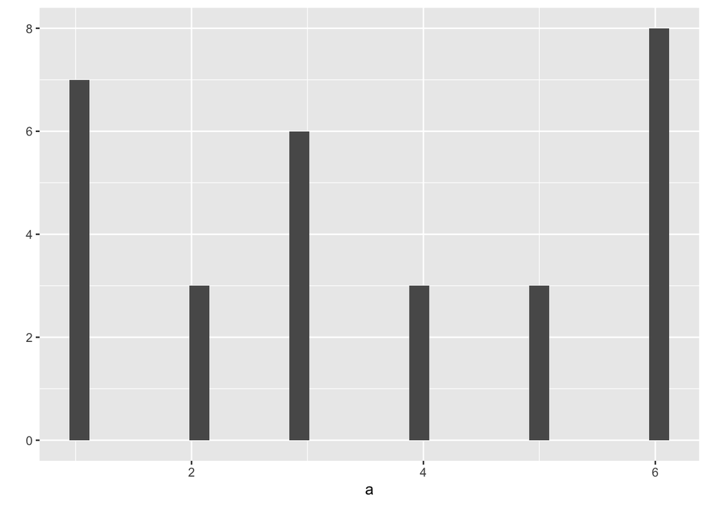

```r
a<-replicate(30,sz_1())
library(ggplot2)
qplot(a,binwith=1)
```

we threw one die repeately and observe how the outcomes distribute.Here we plot the numbers of each outcome in Y-axis(as measurement of frequency), the number of the outcomes (1-6)in X-axis.

[output not shown]

```
## [1] 4
```

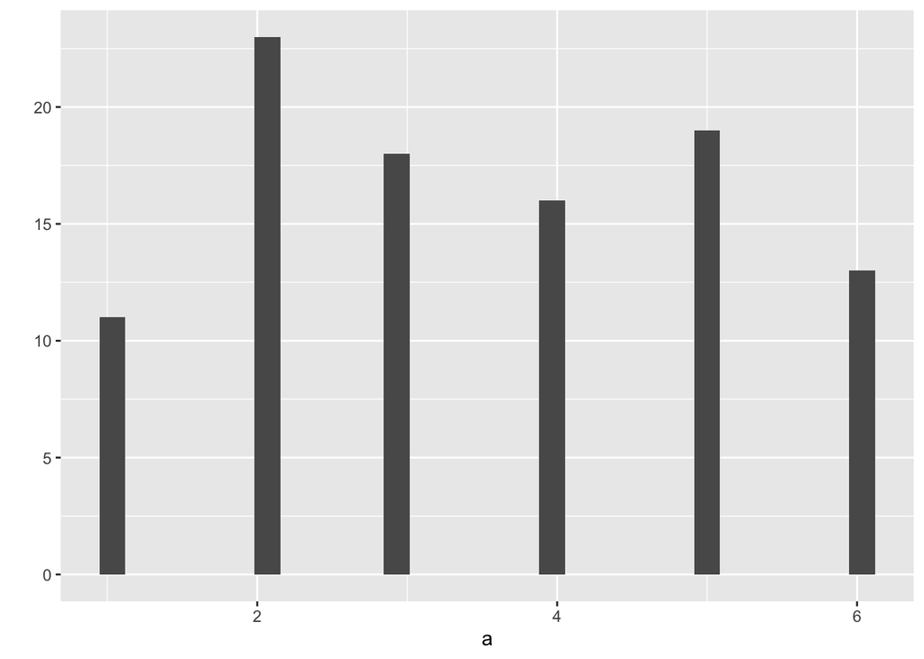

```r
a<-replicate(100,sz_1())
library(ggplot2)
qplot(a,binwith=1)
```

## What about 1000 times

```r
sz_1()
```

```
## [1] 1
```

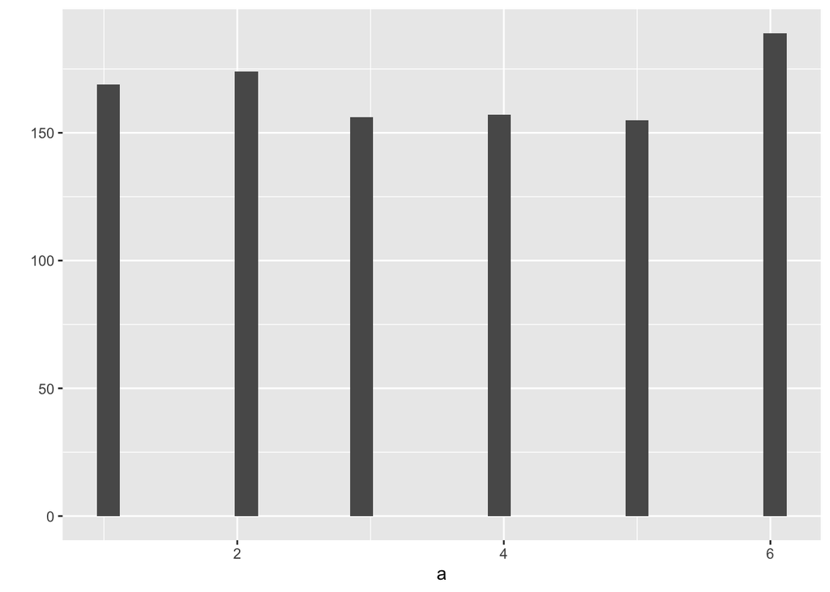

```r
a<-replicate(1000,sz_1())
library(ggplot2)
qplot(a,binwith=1)
```

### With the population becomes larger, the distribution between each side become equally smooth bit by bit.

##EP2##